# Calcolo p value, t critico e IC

Autore/Autrice

Ottavia Epifania

# Introduzione

In questo file vengono illustrati i principi per calcolare i $p$ value a partire dalla statistica test $t_o$, i valori di t critico $t_c$ dato un valore di $\alpha$ per diversi tipi di ipotesi (bidirezionale, monodirezionale sx, monodirezionale destra) e infine il calcolo degli intervalli di confidenza.

```r
set.seed(999)
x = rnorm(11, mean = 12, sd = 7.5)
mu0 = 10
t.test(x, mu = mu0) # test a due code
```

```
    One Sample t-test

data:  x
t = -0.72806, df = 10, p-value = 0.4833
alternative hypothesis: true mean is not equal to 10
95 percent confidence interval:
  3.50030 13.29817
sample estimates:
mean of x
 8.399236
```

```r
t.test(x, mu = mu0,
       alternative = "greater") # test a una coda destra
```

```
    One Sample t-test

data:  x
t = -0.72806, df = 10, p-value = 0.7584
alternative hypothesis: true mean is greater than 10
95 percent confidence interval:
 4.414237      Inf
sample estimates:
mean of x
 8.399236
```

```r
t.test(x, mu = mu0,
       alternative = "less") # test a una coda sinistra
```

```
    One Sample t-test

data:  x
t = -0.72806, df = 10, p-value = 0.2416
alternative hypothesis: true mean is less than 10
95 percent confidence interval:
     -Inf 12.38424
sample estimates:
mean of x
 8.399236
```

# Calcolo p-value

Come prima cosa, salviamo i risultati di uno dei test per avere la statistica test sempre disponibile

**ATTENZIONE!**

La statistica $t_o$ è sempre la stessa, indipendentemente dall’ipotesi, fintanto che $N$ (e quindi $gdl$) e $\mu_0$ sono invariati

```r
mytest = t.test(x, mu = mu0) # test a due code
mytest$statistic
```

```
        t
-0.728061
```

## Ipotesi bidirezionale

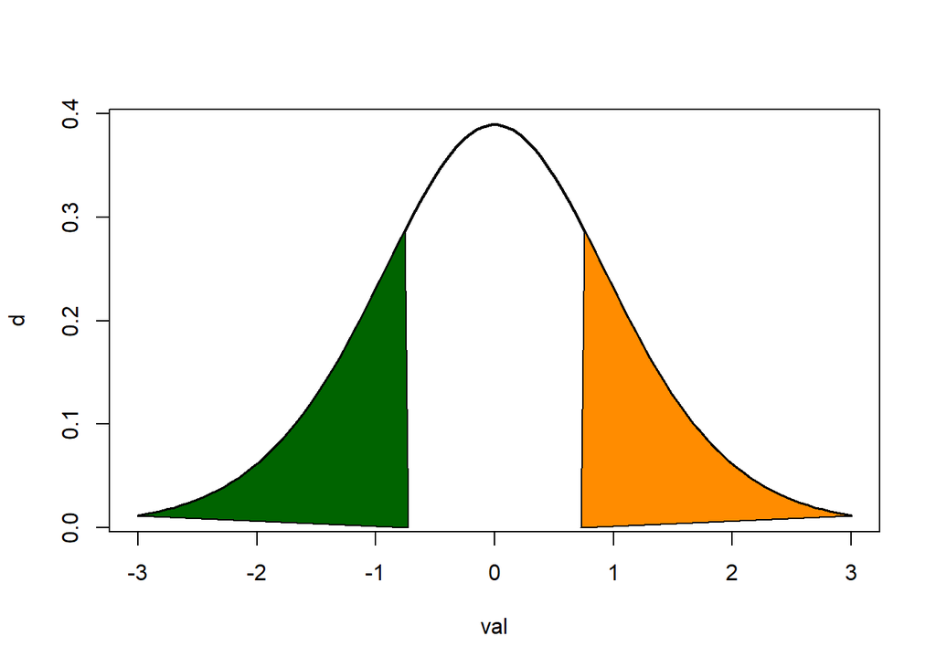

L’area sottesa alla curva evidenziata in verde è:

$$\int_{-\infty}^{-t_0} f_T(t \mid \theta) \, dt$$
e si ottiene con il codice:

```r
pt(mytest$statistic, 10)
```

```
        t
0.2416378
```

L’area sottesa alla curva evidenziata in arancione è:

$$\int_{+t_0}^{+\infty} f_T(t \mid \theta) \, dt$$

e si ottiene con il codice:

```r
1-pt(abs(mytest$statistic), 10) # il valore assoluto è necessario perché la
```

```
        t
0.2416378
```

```r
                               # statistica test è negativa
```

Ma sono uguali per la simmetria della distribuzione di probabilità di riferimento. Per il calcolo del p-value del test quindi si può applicare il codice:

```r
2*(1-pt(abs(mytest$statistic), 10))
```

```
        t
0.4832757
```

che è uguale al valore del $p$ value ottenuto mediante l’applicazione del test:

```r
mytest$p.value
```

```
[1] 0.4832757
```

## Ipotesi monodirezionale sinistra

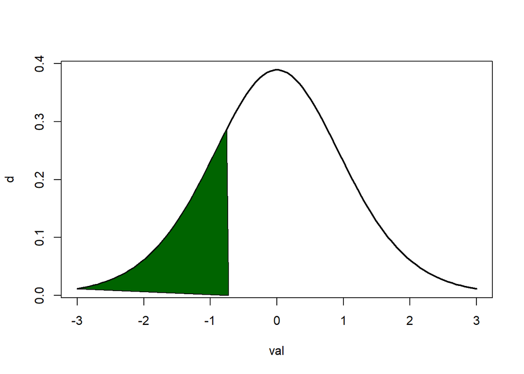

L’area sottesa alla curva evidenziata in verde è:

$$\int_{-\infty}^{-t_0} f_T(t \mid \theta) \, dt$$

che si ottiene con il codice:

```r
pt(mytest$statistic, 10)
```

```
        t
0.2416378
```

che infatti è coerente con il valore del p-value ottenuto per il test a una coda sinistra:

```r
testmonosx = t.test(x, mu = mu0,
       alternative = "less")
testmonosx$p.value
```

```
[1] 0.2416378
```

## Ipotesi monodirezionale destra

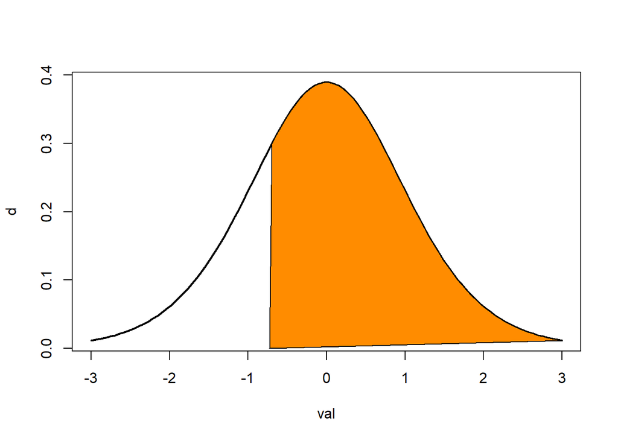

L’area sottesa alla curva evidenziata in arancione è:

$$\int_{t_0}^{+\infty} f_T(t \mid \theta) \, dt$$

e si ottiene con il codice:

```r
1-pt(mytest$statistic, 10) # il valore assoluto è necessario perché la
```

```
        t
0.7583622
```

```r
                               # statistica test è negativa
```

che infatti è coerente con il valore del p-value ottenuto per il test a una coda destra:

```r
testmonodx = t.test(x, mu = mu0,
       alternative = "greater")
testmonodx$p.value
```

```
[1] 0.7583622
```

# Calcolo del t critico $t_c$

Il valore del critico viene definito a seconda di:

- $\alpha$
- Ipotesi alternativa
- Gradi di libertà della distribuzione $t$ di Student

Per il loro calcolo, va usata la funzione `qt(p, df)`, dove $p$ è il valore di probabilità definito da $\alpha$ in base al tipo di ipotesi alternativa (mono vs. bidirezionale) e $df$ sono i gradi di libertà legati alla distribuzione.

## Ipotesi bidirezionale

Per $\alpha = .05$ e ipotesi bidirezionale, con la distribuzione di riferimento con $gdl = 10$, $t_c$ si ottiene con:

```r
qt(.025, df = 10)
qt(.975, df = 10)
```

**1**

Restituisce il valore del quantile che è preceduto dallo .025 di probabilità

**2**

Restituisce il valore del quantile che è preceduto dallo .975 di probabilità

```
[1] -2.228139
[1] 2.228139
```

## Ipotesi monodirezionale sx

```r
qt(.025, df = 10)
```

```
[1] -2.228139
```

## Ipotesi monodirezionale dx

```r
qt(.975, df = 10)
```

```
[1] 2.228139
```

## In generale

Cambiando i valori di probabilità $p$ si esplicita il valore di $\alpha$ di riferimento:

```r
qt(.90, 10)
qt(.10, 10)
```

**1**

$\alpha = .10$ e ipotesi monodirezionale destra

**2**

$\alpha = .10$ e ipotesi monodirezionale sinistra

```
[1] 1.372184
[1] -1.372184
```

# Intervallo di confidenza

L’intervallo di confidenza viene calcolato come:

$$IC_p = \bar{x}\pm t_c * \sigma_{\bar{x}}$$
Dove $p$ è la probabilità determinata come $1 -\alpha$, $t_p$ è il valore di $t$ critico per $\alpha$ (con hp bidirezionale) e $\sigma_{\bar{x}}$ è l’errore standard ottenuto come:

```r
mx = mean(x)
se = sqrt(var(x)/length(x))
tc = qt((1-.10/2), df = 10)
mx - tc*se
mx + tc*se
```

**1**

Media di $x$

**2**

Standard error

**5**

Limite inferiore dell’intervallo

**6**

Limite superiore dell’intervallo

```
[1] 4.414237
[1] 12.38424
```